# Nordic Ski Analysis

Daniel Muzyka

2/10/2022

## Loading Libraries

```r
library(tidyverse)
library(hexbin)
```

## Reading in Data

Pulling my data straight from Github and filtering for Nordic Skiing data

```r
strava <- readRDS(gzcon(url("https://github.com/muzykad397/strava/blob/main/data/strava.RDS?raw=true")))

#this is an analysis for nordic skiing only so I will filter the data now
nordic <- strava %>% filter(type=="NordicSki")
```

# Basic Plots

### Histograms

##### Looking at distributions

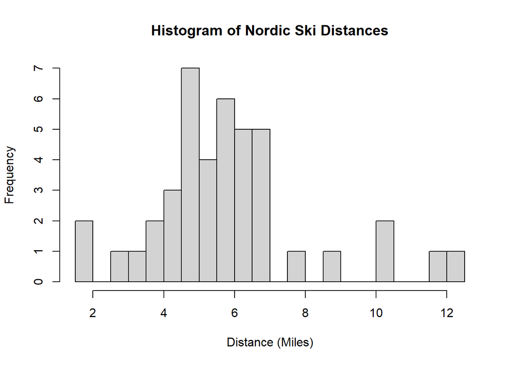

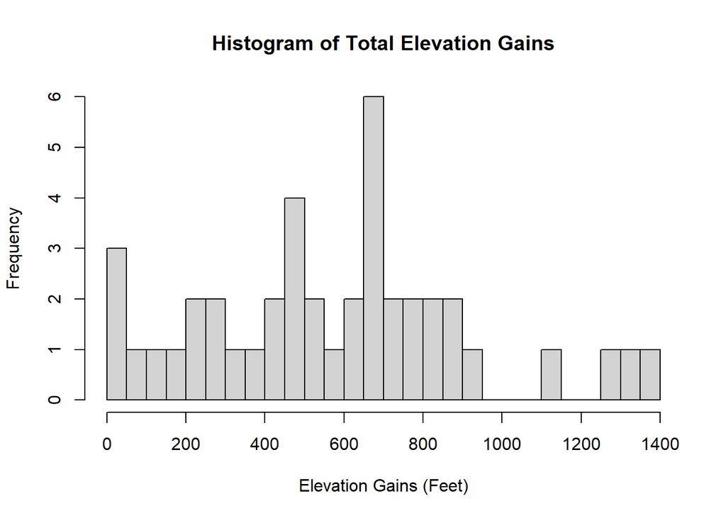

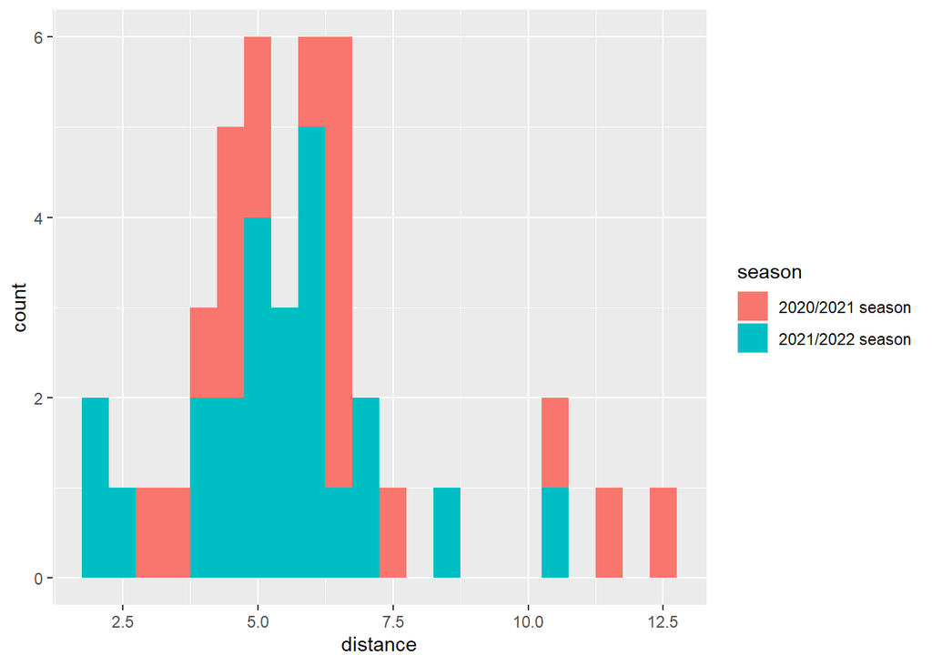

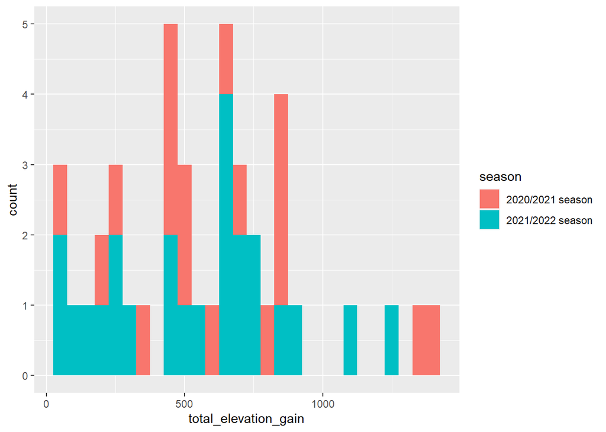

## Looking at relationships

### Scatter Plots

We can see in general there is a relationship between distance and total elevation gain. This overall is not surprising because my main venue of Mt. Spokane features rolling hills.

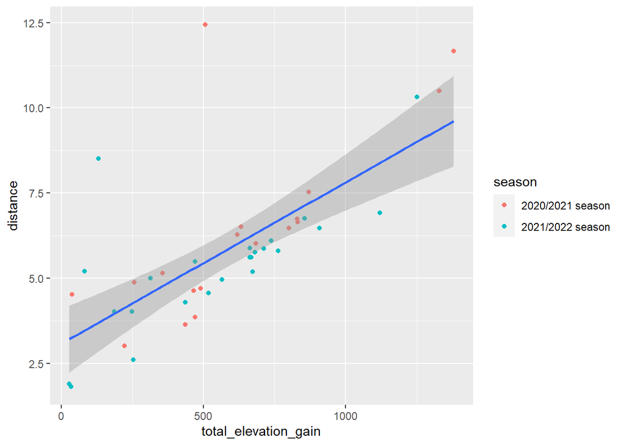

```r
#scatter plot of elevation gain * distance with a linear model fit at .05 alpha
nordic %>% ggplot() + geom_point(aes(x=total_elevation_gain, y=distance, color=season)) +
  geom_smooth(aes(x=total_elevation_gain, y=distance),method=lm, formula=y~x, level=0.95)
```

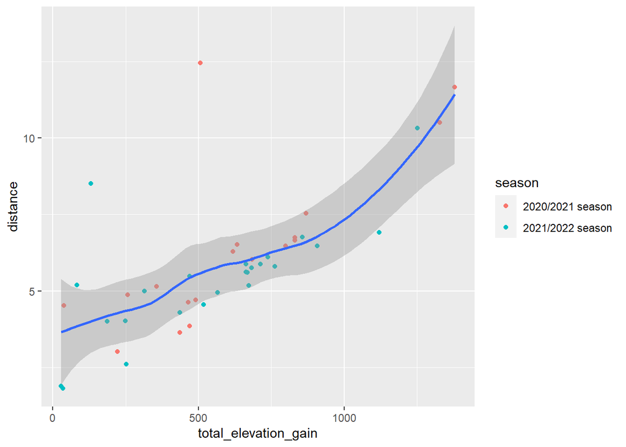

```r
#scatter plot of elevation gain * distance with a loess fit at .05 alpha
nordic %>% ggplot() + geom_point(aes(x=total_elevation_gain, y=distance, color=season)) +
  geom_smooth(aes(x=total_elevation_gain, y=distance),method=loess,formula=y~x, level=0.95)
```

### Hexplot

In the hexplot I am starting to see a frequency in the center showing my typical ski is around 6 miles and 750 feet of elevation gain.

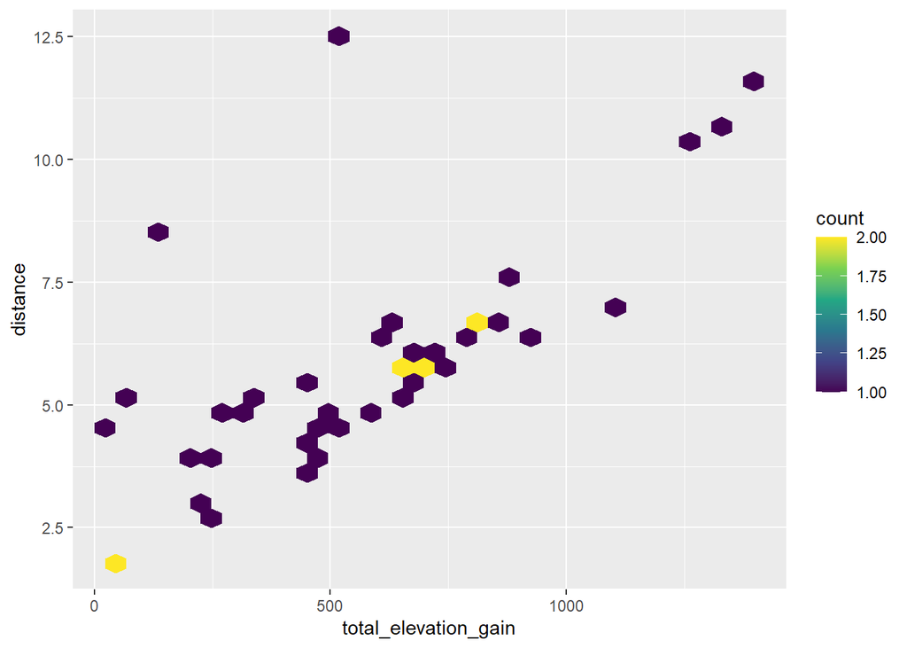

```r
#Hexbin to show not only relationshp, but frequency of the points
nordic %>% ggplot(aes(x = total_elevation_gain, y = distance)) +
  geom_hex() +
  scale_fill_viridis_c()
```

### Barchart

Here we can see nice distributions for my distance traveled and elevation climbed per month.

I wonder if there is a third variable involved…***

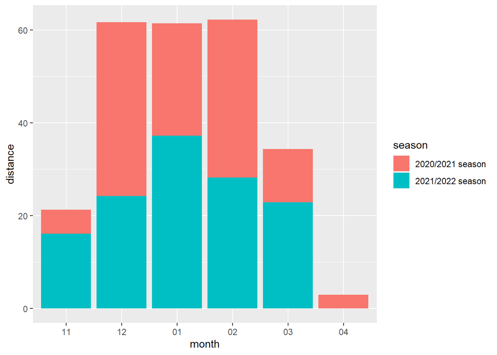

```r
#reorder month for a nice curve through the winter months
nordic$month = with(nordic, reorder(month, month_order))

nordic  %>%  ggplot() + geom_col( aes(x=month,y=distance,fill=season))
```

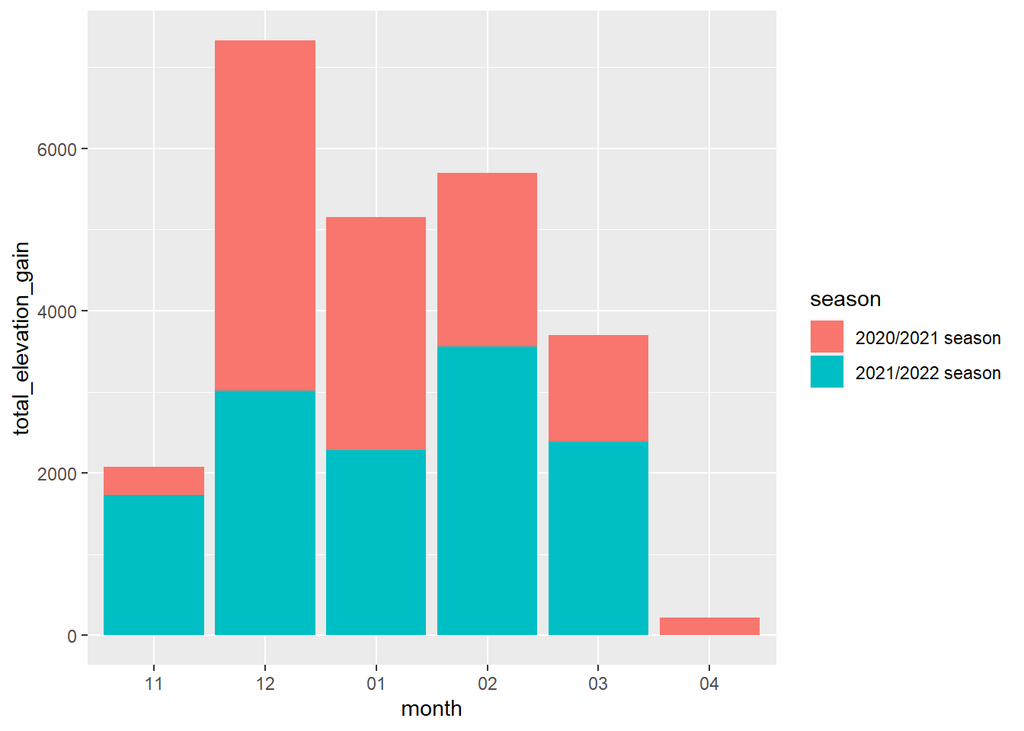

```r
nordic  %>%  ggplot() + geom_col( aes(x=month,y=total_elevation_gain,fill=season))
```

## Creating seasonal summary data

I would like to plot my season totals in a cumulative fashion. This will help me see if I am getting more skiing done compared to last year around this time.

This step is creating the aggregated data

```r
#I still need to add cumulative totals.
#Before I do this I want to fill any months without data with a 0 mileage for illustration purposes
#for example, one season starts earlier, or in one season I happen to not ski an entire month
min<-nordic %>%  summarise(.,min(month_order))
max<-nordic %>%  summarise(.,max(month_order))
seasons <- nordic %>% distinct(.,season)
month_translate <- nordic %>% group_by(month,month_order) %>% distinct(month,month_order) %>% ungroup()

min_to_max <- data.frame(month_order=min$'min(month_order)':max$'max(month_order)',
                        distance=0,
                        total_elevation_gain=0)  %>%
  full_join(.,month_translate, by="month_order") %>% full_join(.,seasons,by=character())



summaries <- bind_rows(nordic,min_to_max) %>% group_by(season,month,month_order) %>%
  summarise(mileage = sum(distance),
            elevation_gain = sum(total_elevation_gain),
                              .groups = 'drop') %>%
  arrange(season,month_order) %>% group_by(season) %>%
  mutate(.,cum_mileage=cumsum(mileage)) %>%
  mutate(.,cum_elevation=cumsum(elevation_gain))


summaries$month = with(summaries, reorder(month, month_order))
```

## Plotting Season to Date totals

Now that I have summarized data, I would like to plot it.

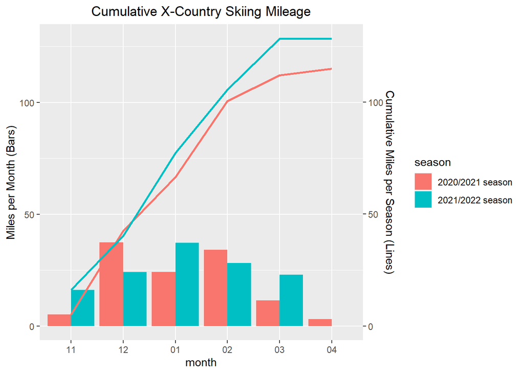

```r
summaries %>%
ggplot(.,aes(x=month)) + ggtitle("Cumulative X-Country Skiing Mileage") +
   theme(plot.title = element_text(hjust = 0.5)) +
  geom_bar( aes(y=mileage,group=season,fill=season), stat="identity" , position="dodge") +
 geom_line( aes(y=cum_mileage, group=season, color=season),stat="identity", size=1) +

  scale_y_continuous(
    name="Miles per Month (Bars)",
    sec.axis = sec_axis(~.,name="Cumulative Miles per Season (Lines)")

  )
```

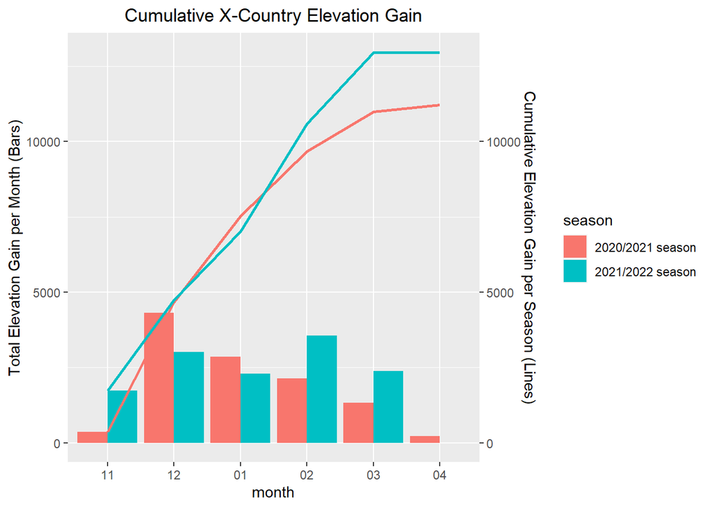

```r
summaries %>%
ggplot(.,aes(x=month)) + ggtitle("Cumulative X-Country Elevation Gain") +
   theme(plot.title = element_text(hjust = 0.5)) +
  geom_bar( aes(y=elevation_gain,group=season,fill=season), stat="identity" , position="dodge") +
 geom_line( aes(y=cum_elevation, group=season, color=season),stat="identity", size=1) +

  scale_y_continuous(
    name="Total Elevation Gain per Month (Bars)",
    sec.axis = sec_axis(~.,name="Cumulative Elevation Gain per Season (Lines)")

  )
```